# bike_explor-Copy1

This Project will cover the following sections over this notebook :

- Data Wrangling
- Data Cleaning
- Explaratory data analysis and univariate vasuliazation
- Bivariate Visualization
- Multivariate Vasualization

# Data Wrangling

### The dataset orginially contains about 183k rows and 16 columns with no duplicated records, while some contain null data but less than 5% of the whole data

# Explaratory data analysis and univariate vasuliazation

## Is there a difference in gender distribution ?

### males are more than females in both subscribers and customers

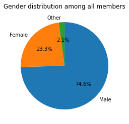

```python
gen_count = df.member_gender.value_counts()
plt.pie(gen_count, labels = gen_count.index, startangle = 90, counterclock = False,autopct='%1.1f%%')
plt.title("Gender distribution among all members");
```

## What is the age distribution?

### Most Members are between 20 and 40 years old

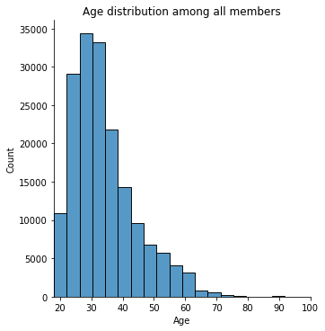

```python
sb.displot(df["Age"], kind = 'hist', bins = 30)
plt.xlim(18,100)
plt.title("Age distribution among all members");
```

## What is the average trip duration?

### The most frequent duration for trips is between 3 and 9 minutes

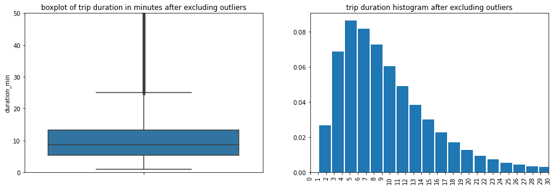

```python
plt.figure(figsize = [16, 5])
plt.subplot(1, 2, 1)

sb.boxplot(y = df['duration_min'],color=base_color)
plt.ylim((0,50))
plt.title("boxplot of trip duration in minutes after excluding outliers");

plt.subplot(1, 2, 2)

plt.hist(data = df_duration, x = 'duration_min', bins = 30, rwidth = 0.9, density = True)
plt.xlim(0,30)
x_ticks = (np.arange(0, 31, step=1))
plt.xticks(ticks=x_ticks, rotation = 90)
plt.title("trip duration histogram after excluding outliers");
```

## Peak time analysis

### Most rides take place at two intervals ; between 8 to 9 am and between 5 to 6 pm

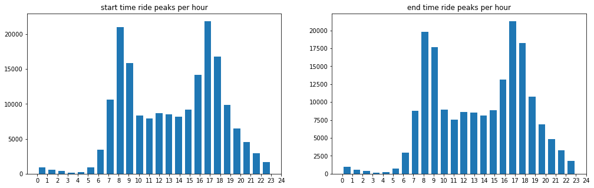

```python
plt.figure(figsize = [17, 5])


plt.subplot(1,2,1)
plt.hist(x = df["st_hours"], bins = 24, rwidth = 0.7)
x_ticks = (np.arange(0, 25, step=1))
plt.xticks(ticks=x_ticks)
plt.title("start time ride peaks per hour");


plt.subplot(1,2,2)
plt.hist(x = df["en_hours"], bins = 24, rwidth = 0.7)
x_ticks = (np.arange(0, 25, step=1))
plt.xticks(ticks=x_ticks)
plt.title("end time ride peaks per hour");
```

### no significant difference in the minutes where rides start and end

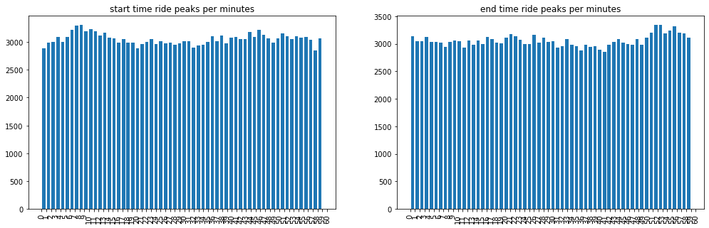

```python
plt.figure(figsize = [17, 5])

plt.subplot(1,2,1)
plt.hist(x = df["st_min"], bins = 60, rwidth = 0.7)
x_ticks = (np.arange(0, 61, step=1))
plt.xticks(ticks=x_ticks, rotation = 90)
plt.title("start time ride peaks per minutes");

plt.subplot(1,2,2)
plt.hist(x = df["en_min"], bins = 60, rwidth = 0.7)
x_ticks = (np.arange(0, 61, step=1))
plt.xticks(ticks=x_ticks, rotation = 90)
plt.title("end time ride peaks per minutes");
```

# Bivariate Visualization

## Correlation analysis

```python
x = df.corr()
x.style.background_gradient(cmap='coolwarm')
```

|  | duration_sec | start_station_id | start_station_latitude | start_station_longitude | end_station_id | end_station_latitude | end_station_longitude | bike_id | member_birth_year | st_hours | en_hours | st_min | en_min | Age | duration_min |
| --- | --- | --- | --- | --- | --- | --- | --- | --- | --- | --- | --- | --- | --- | --- | --- |
| duration_sec | 1.000000 | -0.008652 | 0.010513 | -0.037930 | 0.003064 | 0.010873 | -0.038906 | -0.006133 | -0.006027 | 0.006645 | 0.004388 | -0.003398 | 0.001029 | 0.006027 | 1.000000 |
| start_station_id | -0.008652 | 1.000000 | -0.190978 | 0.459169 | 0.336227 | -0.179771 | 0.466755 | -0.064677 | 0.115115 | 0.012272 | 0.010674 | 0.000814 | 0.002018 | -0.115115 | -0.008652 |
| start_station_latitude | 0.010513 | -0.190978 | 1.000000 | -0.677227 | -0.179727 | 0.989969 | -0.682637 | 0.049996 | -0.075826 | -0.017101 | -0.016514 | -0.001344 | -0.002863 | 0.075826 | 0.010513 |
| start_station_longitude | -0.037930 | 0.459169 | -0.677227 | 1.000000 | 0.479688 | -0.681815 | 0.992410 | -0.141782 | 0.125590 | 0.053245 | 0.049736 | -0.003071 | -0.004989 | -0.125590 | -0.037930 |
| end_station_id | 0.003064 | 0.336227 | -0.179727 | 0.479688 | 1.000000 | -0.197992 | 0.469027 | -0.054607 | 0.112709 | 0.090772 | 0.089351 | 0.001524 | -0.002507 | -0.112709 | 0.003064 |
| end_station_latitude | 0.010873 | -0.179771 | 0.989969 | -0.681815 | -0.197992 | 1.000000 | -0.684197 | 0.049244 | -0.075927 | -0.033929 | -0.033072 | -0.001025 | -0.002702 | 0.075927 | 0.010873 |
| end_station_longitude | -0.038906 | 0.466755 | -0.682637 | 0.992410 | 0.469027 | -0.684197 | 1.000000 | -0.143527 | 0.126421 | 0.033620 | 0.030163 | -0.001978 | -0.003500 | -0.126421 | -0.038906 |
| bike_id | -0.006133 | -0.064677 | 0.049996 | -0.141782 | -0.054607 | 0.049244 | -0.143527 | 1.000000 | 0.036145 | 0.016488 | 0.016320 | 0.002184 | 0.003033 | -0.036145 | -0.006133 |
| member_birth_year | -0.006027 | 0.115115 | -0.075826 | 0.125590 | 0.112709 | -0.075927 | 0.126421 | 0.036145 | 1.000000 | 0.064090 | 0.062263 | -0.003123 | -0.003568 | -1.000000 | -0.006027 |
| st_hours | 0.006645 | 0.012272 | -0.017101 | 0.053245 | 0.090772 | -0.033929 | 0.033620 | 0.016488 | 0.064090 | 1.000000 | 0.981298 | -0.067989 | -0.024037 | -0.064090 | 0.006645 |
| en_hours | 0.004388 | 0.010674 | -0.016514 | 0.049736 | 0.089351 | -0.033072 | 0.030163 | 0.016320 | 0.062263 | 0.981298 | 1.000000 | -0.027722 | -0.063758 | -0.062263 | 0.004388 |
| st_min | -0.003398 | 0.000814 | -0.001344 | -0.003071 | 0.001524 | -0.001025 | -0.001978 | 0.002184 | -0.003123 | -0.067989 | -0.027722 | 1.000000 | 0.244029 | 0.003123 | -0.003398 |
| en_min | 0.001029 | 0.002018 | -0.002863 | -0.004989 | -0.002507 | -0.002702 | -0.003500 | 0.003033 | -0.003568 | -0.024037 | -0.063758 | 0.244029 | 1.000000 | 0.003568 | 0.001029 |
| Age | 0.006027 | -0.115115 | 0.075826 | -0.125590 | -0.112709 | 0.075927 | -0.126421 | -0.036145 | -1.000000 | -0.064090 | -0.062263 | 0.003123 | 0.003568 | 1.000000 | 0.006027 |
| duration_min | 1.000000 | -0.008652 | 0.010513 | -0.037930 | 0.003064 | 0.010873 | -0.038906 | -0.006133 | -0.006027 | 0.006645 | 0.004388 | -0.003398 | 0.001029 | 0.006027 | 1.000000 |

### in average, female members are younger than males while others are the oldest

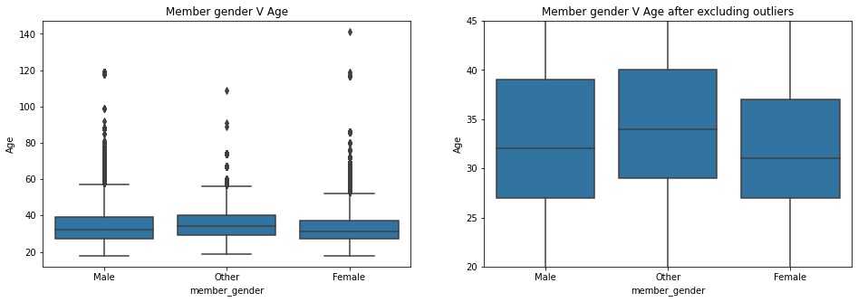

```python
plt.figure(figsize = [16, 5])
plt.subplot(1, 2, 1)
sb.boxplot(data=df, x='member_gender', y='Age', color=base_color)
plt.title("Member gender V Age");

plt.subplot(1, 2, 2)
sb.boxplot(data=df, x='member_gender', y='Age', color=base_color)
plt.title("Member gender V Age after excluding outliers");
plt.ylim(20,45);
```

## does being a customer or subscriber will change the gender distribution ?

### Males are more than females in both customers and subscribers while others are the least in both

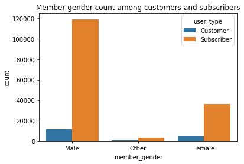

```python
sb.countplot(data = df, x = 'member_gender', hue = 'user_type');
plt.title("Member gender count among customers and subscribers");
```

## Is there a difference in age between subscribers and customers?

### No difference in Age between subscribers and customers

```
(15.0, 70.0)
```

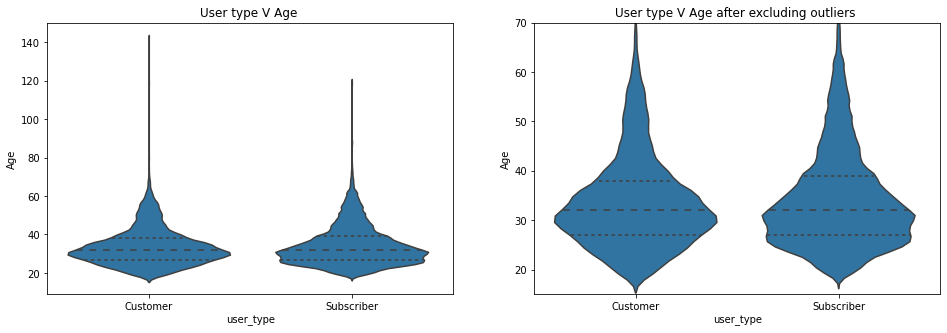

```python
plt.figure(figsize = [16, 5])
plt.subplot(1, 2, 1)
sb.violinplot(data=df, x='user_type', y='Age', color=base_color, inner='quartile');
plt.title("User type V Age ");

plt.subplot(1, 2, 2)
sb.violinplot(data=df, x='user_type', y='Age', color=base_color, inner='quartile');
plt.title("User type V Age after excluding outliers ");
plt.ylim(15, 70)
```

## Does age affect trip duration ?

### Members in age range between 20 and 40 years old take longer time in trips

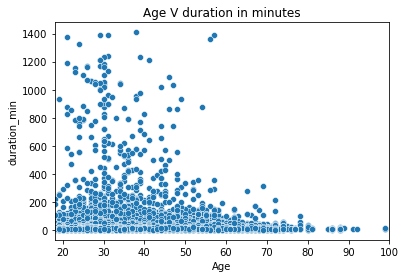

```python
sb.scatterplot(data = df, x = 'Age', y = 'duration_min');
plt.xlim(18,100);
plt.title("Age V duration in minutes");
```

# Multivariate Visualization

## Does being a customer or subscriber change the relation between age and trip durations ?

### No signifcant difference between customers and subscribers of same age in trip duration

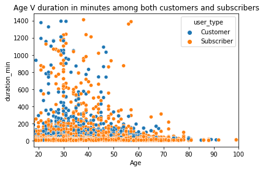

```python
sb.scatterplot(data = df, x = 'Age', y = 'duration_min',hue = 'user_type');
plt.xlim(18, 100);
plt.title("Age V duration in minutes among both customers and subscribers");
```

## What is the relation between start hours of the trip, duration among customers and subscribers ?

### Customers take longer trip durations than suscribers with the peak between 1 and 4 am

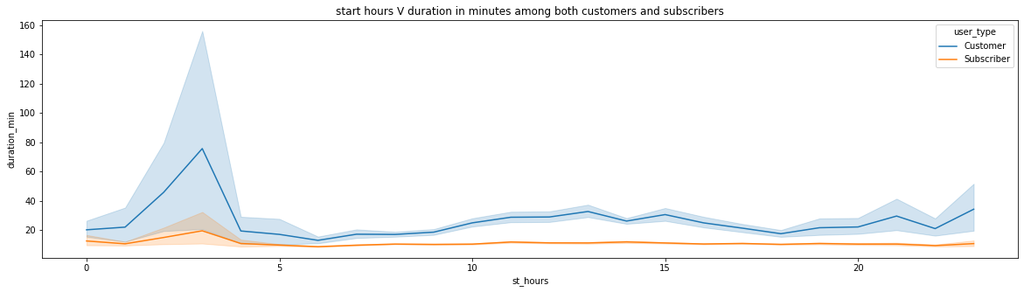

```python
plt.figure(figsize = [20,5]);
sb.lineplot(data = df, x = 'st_hours', y = 'duration_min', hue = 'user_type');
plt.title("start hours V duration in minutes among both customers and subscribers");
```

## What is the relation between start hours of the trip, duration among differenet genders?

### people of other genders take longer trip duration than females while males are the least

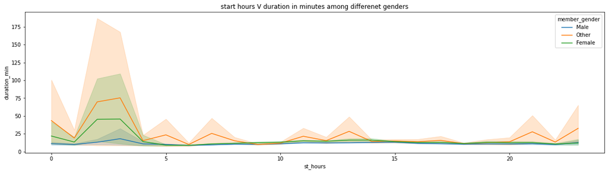

```python
plt.figure(figsize = [20,5]);
sb.lineplot(data = df, x = 'st_hours', y = 'duration_min', hue = 'member_gender');
plt.title("start hours V duration in minutes among differenet genders");
```